# Overview of katdetectr

Daan Hazelaar and Job van Riet

23 May 2022

#### Package

katdetectr 0.99.0

# 1 Abstract

`katdetectr` is an *R* package for the detection, characterization and visualization of localized hypermutated regions, often referred to as *kataegis*.

Please see the [Application Note](https://www.google.com) (under submission) for additional background, details and performance evaluations of `katdetectr`.

The general workflow of `katdetectr` can be summarized as follows:

1. Import of genomic variants; VCF, MAF or VRanges objects.
2. Detection of kataegis foci.
3. Visualization of segmentation and kataegis foci.

Below, this workflow is performed in a step-by-step manner on publicly-available datasets which are included within this package.

# 2 Importing genomic variants

Genomic variants from multiple common data-formats (VCF/MAF and VRanges objects) can be imported into katdetectr. These can be contain either single or multiple samples, in which case records can be aggregated by setting `aggregateRecords = TRUE`. Overlapping genomic variants (e.g., an InDel and SNV) are reduced into a single record.

From these genomic variants, we calculate the intermutation distance (IMD). The IMD is defined as the genomic distance (in bp) between a genomic variant and it’s respective nearest upstream genomic variant (5’ A <- B 3’).

```r
# Genomic variants stored within the VCF format.
pathToVCF <- system.file(package = "katdetectr", "extdata/CPTAC_Breast.vcf")

# Genomic variants stored within the MAF format.
pathToMAF <- system.file(package = "katdetectr", "extdata/APL_primary.maf")

# In addition, we can generate synthetic genomic variants with interjected kataegis regions
# using generateSyntheticData(). This will output a VRanges object.
syntheticData <- generateSyntheticData(nBackgroundVariants = 2500, nKataegisFoci = 1)
```

# 3 Detection of kataegis foci

Using `detectKataegis()`, we can employ changepoint detection to detect distinct clusters of varying IMD and size. Various underlying parameters can be altered to improve or alter the default methodology.

```r
# Detect kataegis foci within the given VCF file.
kdVCF <- detectKataegis(genomicVariants = pathToVCF)

# # Detect kataegis foci within the given MAF file.
# As this file contains multiple samples, we set aggregateRecords = TRUE.
kdMAF <- detectKataegis(genomicVariants = pathToMAF, aggregateRecords = TRUE)

# Detect kataegis foci within our synthetic data.
kdSynthetic <- detectKataegis(genomicVariants = syntheticData)
```

All relevant input and subsequent results are stored within `KatDetect` objects. Using `summary()`, `show()` and/or `print()`, we can generate overviews of these `KatDetect` object(s).

```r
summary(kdVCF)
```

```
## Sample name:                                 CPTAC
## Total number of genomic variants:            3684
## Total number of putative Kataegis foci:      10
## Total number of variants in a Kataegis foci: 140
```

```r
print(kdVCF)
```

```
## Sample name:                                 CPTAC
## Total number of genomic variants:            3684
## Total number of putative Kataegis foci:      10
## Total number of variants in a Kataegis foci: 140
```

```r
show(kdVCF)
```

```
## Class 'KatDetect' : KatDetect Object
##                   : S4 class containing 4 slots with names:
##                     kataegisFoci genomicVariants segments info
##
## Created on:         Mon May 23 13:28:08 2022
## katdetectr version: 0.99.0
##
## summary:
## --------------------------------------------------------
## Sample name:                                 CPTAC
## Total number of genomic variants:            3684
## Total number of putative Kataegis foci:      10
## Total number of variants in a Kataegis foci: 140
## --------------------------------------------------------
```

```r
# Or simply:
kdVCF
```

```
## Class 'KatDetect' : KatDetect Object
##                   : S4 class containing 4 slots with names:
##                     kataegisFoci genomicVariants segments info
##
## Created on:         Mon May 23 13:28:08 2022
## katdetectr version: 0.99.0
##
## summary:
## --------------------------------------------------------
## Sample name:                                 CPTAC
## Total number of genomic variants:            3684
## Total number of putative Kataegis foci:      10
## Total number of variants in a Kataegis foci: 140
## --------------------------------------------------------
```

Underlying data can be retrieved from these `KatDetect` objects by the following functions:

```r
# Processed genomic variants used as input for changepoint detection.
getGenomicVariants(kdVCF)

# GRanges containing the segments as derived from changepoint detection.
getSegments(kdVCF)

# GRanges containing segments designated as putative kataegis foci.
getKataegisFoci(kdVCF)

# Supplementary information.
getInfo(kdVCF)
```

# 4 Visualization of segmentation and kataegis foci

Per sample, we can visualize the IMD, detected segments and putative kataegis foci as a rainfall plot. In addition, this allows for a per-chromosome approach which can highlight the putative kataegis foci.

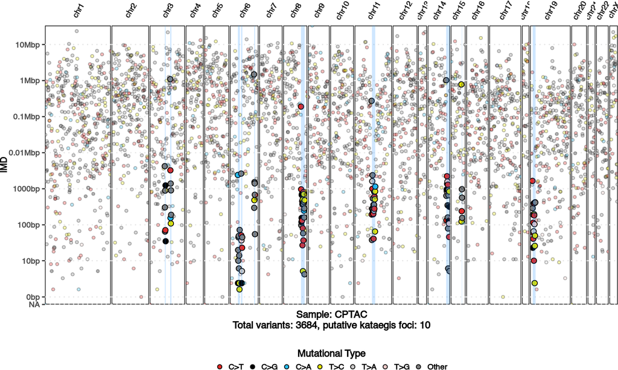

```r
rainfallPlot(kdVCF)
```

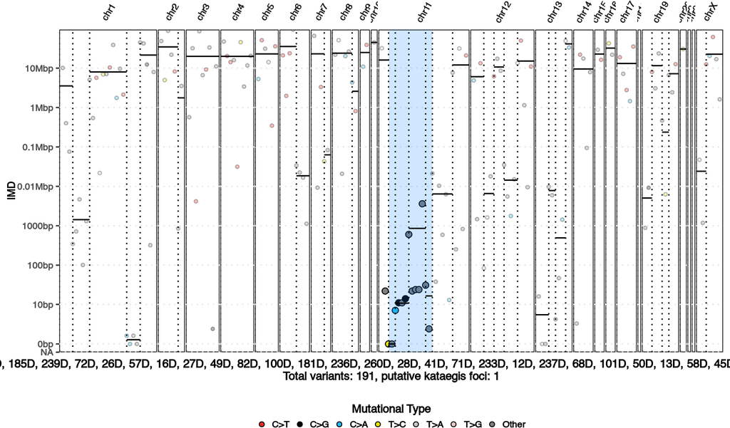

```r
# With showSegmentation, the detected segments (changepoints) as visualized with their mean IMD.
rainfallPlot(kdMAF, showSegmentation = TRUE)
```

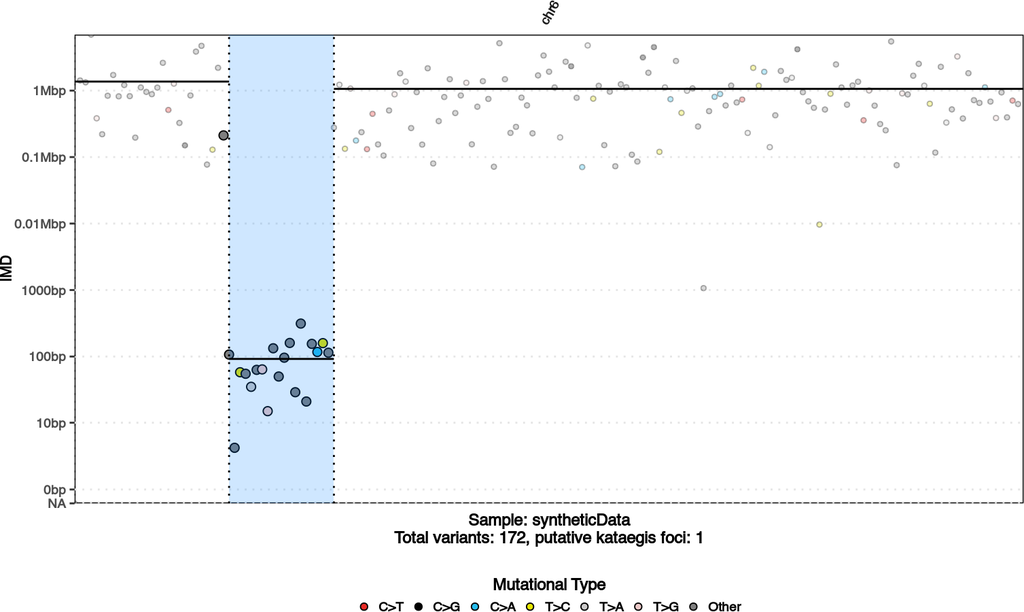

```r
# With showSequence, we can display specific chromosomes or all chromosomes in which a putative kataegis foci has been detected.
rainfallPlot(kdSynthetic, showKataegis = TRUE, showSegmentation = TRUE, showSequence = "Kataegis")
```